# Exercise 6: Data Wrangling Pt 1

# Importing Messy Excel Data

Although your data may be in a spreadsheet or CSV file, it may not be in an ideal format. See this registration list:

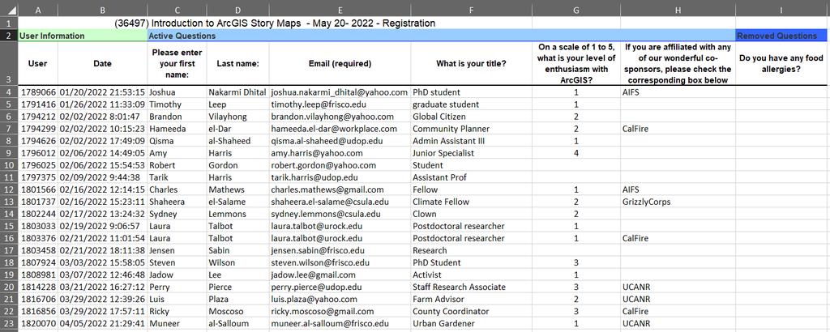

Here we see a bunch of stuff before the data, the column “names” are unwieldy, there are several extra columns we don’t need, missing values, etc.

Likewise, the [readr](https://readr.tidyverse.org/) package provides super-charged functions for importing and exporting rectangular data in text formats.

**Take Home Messages**

- Data wrangling starts when you import
- You’re not limited to just using `read.csv()`

# `dplyr` methods

Load dplyr:

We can proactively prevent function name clashes with the `conflicted` package:

## Subset Columns

You can also **rename** columns with `select()` (dplyr also has a `rename()` function):

If you want to extract the values from a single column and get the results back as a vector, use `pull()` (similar to the `$` operator):

## Adding/Modifying Columns

`mutate()` can also be used to modify existing columns, for example we could round bill_flip_ratio to 3 decimal places.

**CHALLENGE #1**: Add a column called `bill_flip_sum` which represents the sum of the bill and flipper length.

Hint: use `mutate()`

```r
## Your answer here
```

# Managing Rows

## Sorting

You can **sort** a table using `arrange()`, passing the column(s) you want to sort by. The default sort order is ascending, but you can change that to descending by wrapping the column name in `desc()`.

## Subsetting

The two functions most commonly used to subset rows include `filter()` and `slice()`.

- use `slice()` to subset based on indices
- use `filter()` to subset based on a logical expressions

Logical expressions you can use in `filter()` include:

[figure not shown]

If you want to filter on two criteria, add a second expression to `filter()`:

**CHALLENGE #2**: Write an expression that pulls out just the males on Torgersen Island. HOw many are there?

Tip: For challenge questions 2 & 3, mix and match the following functions:

`select()`, `mutate()`, `pull()`, `arrange()`, `filter()`, `slice()`

```r
## Your answer here
```

Ans. 23

**CHALLENGE #3**: COmpute the ratio of body mass to bill length and add it as a new column. Return just the species, sex, and this ratio.

```r
# Your answer here
```

# Missing Values

In general you have three options for missing values:

1. Remove any row that has missing values from the data
2. Leave all rows but ignore NA values when you compute summaries (like mean)
3. Estimate or impute them

Suppose we wanted to keep only observations that have no missing values for flipper_length_mm, body_mass_g, and sex.

# Table Summaries

The main dplyr function for creating summaries of data is `summarise()`. The syntax is similar to `mutate()`. Summary columns can use any aggregate function from base R or dplyr (see the [dplyr cheatsheet](https://raw.githubusercontent.com/rstudio/cheatsheets/main/data-transformation.pdf) for a list of functions that are designed to use with `summarise()`).

## Summarise groups of rows

Often you want to create summaries for groups of rows (i.e., a different unit of analysis).

If we wanted to compute summary stats for each species, you would first group the rows by species with `group_by()`, and then use `summarise()`.

**How many rows per island?**

**CHALLENGE #4**: Compute the number of observations per year

```r
## Your answer here
```

**CHALLENGE #5**: Compute the number of observations per year and species?

Hint: `group_by()` can take more than one column

# END

That’s it!